# 08Matplotlib第八段

```python
%%HTML
<style type='text/css'>
    *{
        # background-color:#E3EDCD;
        # background-color:black;
        # color:white;

    }
    h1{
        color:#1976d2;
    }
    h2{
        color:#f57c00;
    }
    h3{
        color:#ba37ff;
    }
    h4{
        color:green;
    }
    table{
        border:1px solid black !important;
        border-collapse:collapse !important;
    }
    th{
        background-color:blueviolet !important;
        text-align:center;
        color:white;
    }
    th,td{
        border:0.1px solid black !important;
        transition:0.2s all liner;

    }
    td:hover{
        transform:scale(1.1);
        background-color:orange;
        color:blueviolet;
    }
    .raw{
        white-space:pre;
    }
    .atcenter{
        text-align:center !important;
    }
    .imp{
        color:red;
        font-weight:bolder;
    }
</style>
```

## 4.16 用Seaborn做数据可视化

虽然 Matplotlib 已经证明了自己绝对是一款超级实用且流行的数据可视 化工具，但是即使骨灰粉也不得不承认它不支持的功能还有很多。 Matplotlib 的三条主要“罪状”总结如下。

- Matplotlib 2.0 之前版本的默认配置样式绝对不是用户的最佳选择。 之前的默认样式还是仿照 1999 年前后的 MATLAB，却一直在使 用。
- Matplotlib 的 API 比较底层。虽然可以实现复杂的统计数据可视 化，但是通常都需要写大量的样板代码（boilerplate code）。
- 由于 Matplotlib 比 Pandas 早十几年，因此它并不是为 Pandas 的 DataFrame 设计的。为了实现 Pandas 的 DataFrame 数据的可视 化，你必须先提取每个 Series，然后通常还需要将它们合并成适 当的格式。如果有一个画图程序库可以智能地使用 DataFrame 的 标签画图，那一定会很棒。

这些问题的终结者就是 Seaborn（[http://seaborn.pydata.org）。Seaborn](http://seaborn.pydata.org%EF%BC%89%E3%80%82Seaborn) 在 Matplotlib 的基础上开发了一套 API，为默认的图形样式和颜色设置提 供了理智的选择，为常用的统计图形定义了许多简单的高级函数，并与 Pandas DataFrame 的功能有机结合。  
说实话，Matplotlib 团队也一直在努力解决这些问题：现在 Matplotlib 中 不仅增加了 plt.style 工具（详情请参见 4.13 节），而且与 Pandas 数 据也可以无缝衔接。Matplotlib 2.0 版已经带有对之前样式优化过的样式 表。但是即使 Matplotlib 已经有了这些进步，Seaborn 仍然是一款非常 好用的附加组件。

### 4.16.1 Seaborn与Matplotlib

```python
import pandas as pd
import matplotlib.pyplot as plt
import numpy as np
plt.style.use('ggplot')
```

创建一些随机游走数据：

```python
rng = np.random.RandomState(0)
x = np.linspace(0, 10, 500)
y = np.cumsum(rng.randn(500, 6), 0)
```

然后画一个简易图形（如图 4-111 所示）：

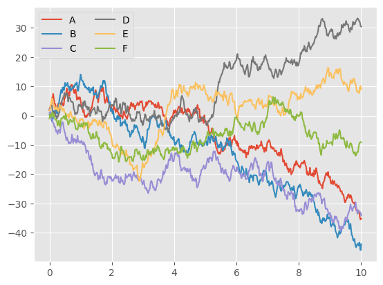

```python
# 用Matplotlib默认样式画图
plt.plot(x, y)
plt.legend('ABCDEF', ncol=2, loc='upper left')
```

尽管最终图形包含了我们想要表达的所有信息，但是其艺术效果并不让 人满意，用 21 世纪的数据可视化审美眼光来看甚至有些过时。  
现在尝试用 Seaborn 来实现。我们会发现，Seaborn 不仅有许多高级的 画图功能，而且可以改写 Matplotlib 的默认参数，从而用简单的 Matplotlib 脚本获得更好的效果。可以用 Seaborn 的 set() 方法设置样 式。为简便起见，将 Seaborn 导入简记为 sns：

```python
import seaborn as sns
sns.set()
```

现在，重新运行之前的两行画图代码（如图 4-112 所示）：

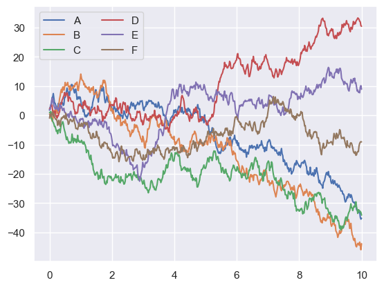

```python
plt.plot(x, y)
plt.legend('ABCDEF', ncol=2, loc='upper left')
```

图 4-112：Seaborn 的默认样式图形

效果确实更好

### 4.16.2 Seaborn图形介绍

Seaborn 的主要思想是用高级命令为统计数据探索和统计模型拟合创建 各种图形。  
下面将介绍一些 Seaborn 中的数据集和图形类型。虽然所有这些图形都 可以用 Matplotlib 命令实现（其实 Matplotlib 就是 Seaborn 的底层）， 但是用 Seaborn API 会更方便。

#### 01. 频次直方图、KDE和密度图

在进行统计数据可视化时，我们通常想要的就是频次直方图和多变 量的联合分布图。在 Matplotlib 里面我们已经见过，相对比较简单 （如图 4-113 所示）：

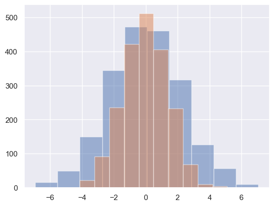

```python
data = np.random.multivariate_normal([0, 0], [[5, 2], [2, 2]], size=2000)
data = pd.DataFrame(data, columns=['x', 'y'])
for col in 'xy':
    plt.hist(data[col], alpha=0.5)
```

图 4-113：频次直方图可视化分布特性

除了频次直方图，我们还可以用 KDE 获取变量分布的平滑估计。 Seaborn 通过 sns.kdeplot 实现（如图 4-114 所示）：

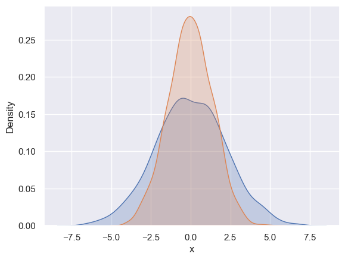

```python
for col in 'xy':
    sns.kdeplot(data[col],fill=True)
```

图 4-114：KDE 可视化分布特性

用 histplot 可以让频次直方图与 KDE 结合起来,注意，需要指明kde=True（如图 4-115 所 示）：

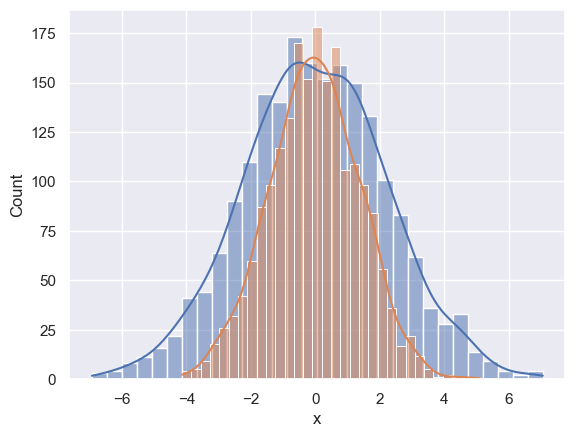

```python
sns.histplot(data['x'],kde=True)
sns.histplot(data['y'],kde=True);
```

图 4-115：频次直方图与 KDE 的结合

```python
sns.histplot?
```

[output not shown]

[output cut: 147 more lines]

[output not shown]

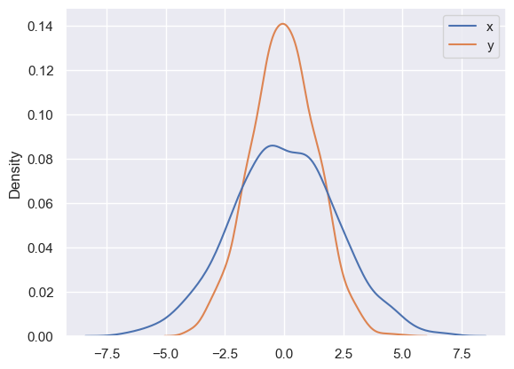

```python
sns.kdeplot(data);
```

用 sns.jointplot 可以同时看到两个变量的联合分布与单变量的 独立分布。在这个图形中，使用白色背景（如图 4-117 所示）：

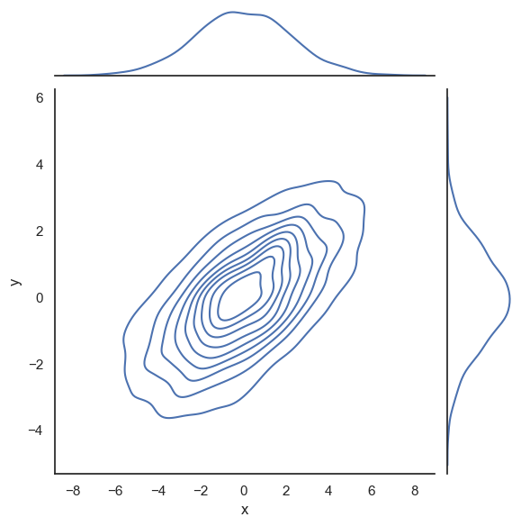

```python
with sns.axes_style('white'):
        sns.jointplot(data,x="x",y="y", kind='kde');
```

图 4-117：二维 KDE 的联合分布图

```python
sns.jointplot?
```

[output not shown]

[output cut: 39 more lines]

[output not shown]

可以向 jointplot 函数传递一些参数。例如，可以用六边形块代 替频次直方图（如图 4-118 所示）：

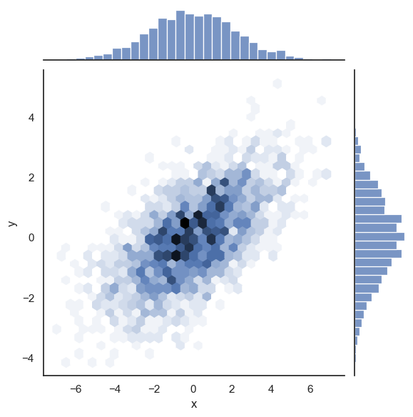

```python
with sns.axes_style('white'):
        sns.jointplot(data=data,x='x',y='y',kind='hex')
```

4-118：用六边形块画的联合分布图

#### 02. 矩阵图

当你需要对多维数据集进行可视化时，最终都要使用矩阵图（pairplot）。如果想画出所有变量中任意两个变量之间的图形，用矩阵 图探索多维数据不同维度间的相关性非常有效。  
下面将用著名的鸢尾花数据集来演示，其中有三种鸢尾花的花瓣与 花萼数据

```python
iris = sns.load_dataset('iris')
```

```python
iris.head()
```

|  | sepal_length | sepal_width | petal_length | petal_width | species |
| --- | --- | --- | --- | --- | --- |
| 0 | 5.1 | 3.5 | 1.4 | 0.2 | setosa |
| 1 | 4.9 | 3.0 | 1.4 | 0.2 | setosa |
| 2 | 4.7 | 3.2 | 1.3 | 0.2 | setosa |
| 3 | 4.6 | 3.1 | 1.5 | 0.2 | setosa |
| 4 | 5.0 | 3.6 | 1.4 | 0.2 | setosa |

可视化样本中多个维度的关系非常简单，直接用 sns.pairplot 即 可（如图 4-119 所示）：

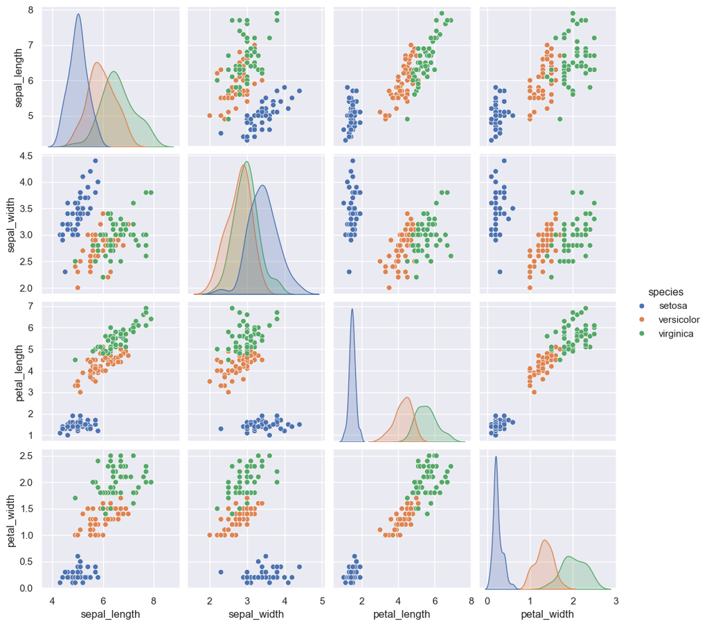

```python
sns.pairplot(iris,hue='species',height=2.5)
```

```python
sns.pairplot?
```

[output not shown]

[output cut: 42 more lines]

[output not shown]

图 4-119：四个变量的矩阵图

#### 03. 分面频次直方图

有时观察数据最好的方法就是借助数据子集的频次直方图。 Seaborn 的 FacetGrid 函数让这件事变得非常简单。来看看某个 餐厅统计的服务员收取小费的数据（如图 4-120 所示）：

```python
tips = sns.load_dataset('tips')
```

```python
tips.head()
```

|  | total_bill | tip | sex | smoker | day | time | size |
| --- | --- | --- | --- | --- | --- | --- | --- |
| 0 | 16.99 | 1.01 | Female | No | Sun | Dinner | 2 |
| 1 | 10.34 | 1.66 | Male | No | Sun | Dinner | 3 |
| 2 | 21.01 | 3.50 | Male | No | Sun | Dinner | 3 |
| 3 | 23.68 | 3.31 | Male | No | Sun | Dinner | 2 |
| 4 | 24.59 | 3.61 | Female | No | Sun | Dinner | 4 |

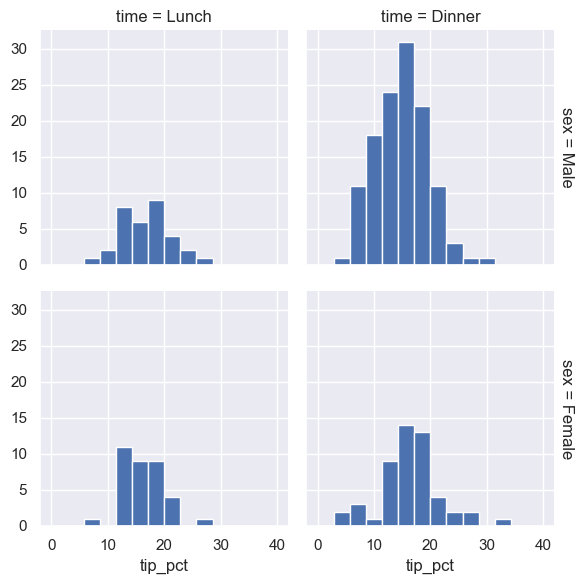

```python
tips['tip_pct'] = 100 * tips['tip'] / tips['total_bill']
grid = sns.FacetGrid(tips, row="sex", col="time", margin_titles=True)
grid.map(plt.hist, "tip_pct", bins=np.linspace(0, 40, 15));
```

图 4-120：分面频次直方图

#### 04. 因子图

因子图（catplot）也是对数据子集进行可视化的方法。你可以通 过它观察一个参数在另一个参数间隔中的分布情况（如图 4-121 所 示）：

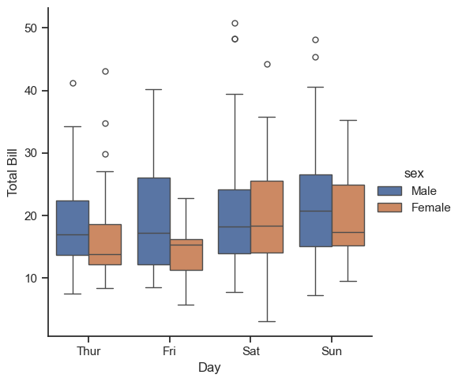

```python
with sns.axes_style(style='ticks'):
    g = sns.catplot(x="day", y="total_bill", hue="sex", data=tips, kind="box")
    g.set_axis_labels("Day", "Total Bill");
```

图 4-121：因子图中不同离散因子的分布对比

#### 05. 联合分布

与前面介绍的矩阵图类似，可以用 sns.jointplot 画出不同数据 集的联合分布和各数据本身的分布（如图 4-122 所示）：

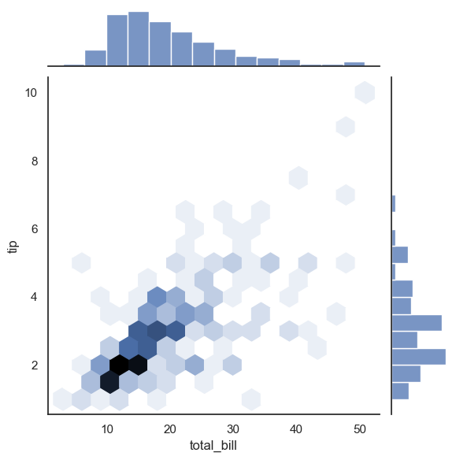

```python
with sns.axes_style('white'):
    sns.jointplot(x="total_bill", y="tip", data=tips, kind='hex')
```

图 4-122：联合分布图

联合分布图也可以自动进行 KDE 和回归（如图 4-123 所示）：

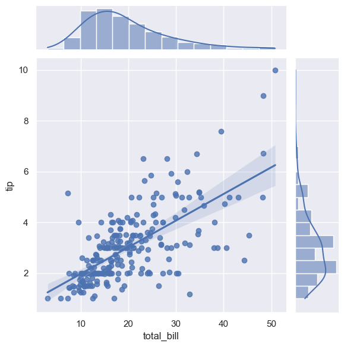

```python
sns.jointplot(x="total_bill", y="tip", data=tips, kind='reg');
```

图 4-123：带回归拟合的联合分布

#### 06. 条形图

```python
planets = sns.load_dataset('planets')
planets.head()
```

|  | method | number | orbital_period | mass | distance | year |
| --- | --- | --- | --- | --- | --- | --- |
| 0 | Radial Velocity | 1 | 269.300 | 7.10 | 77.40 | 2006 |
| 1 | Radial Velocity | 1 | 874.774 | 2.21 | 56.95 | 2008 |
| 2 | Radial Velocity | 1 | 763.000 | 2.60 | 19.84 | 2011 |
| 3 | Radial Velocity | 1 | 326.030 | 19.40 | 110.62 | 2007 |
| 4 | Radial Velocity | 1 | 516.220 | 10.50 | 119.47 | 2009 |

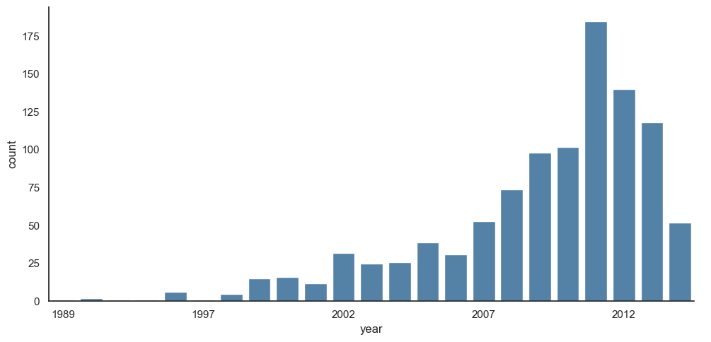

```python
with sns.axes_style('white'):
    g = sns.catplot(x="year", data=planets, aspect=2,
    kind="count", color='steelblue')
    g.set_xticklabels(step=5)
```

图 4-124：频次直方图是因子图的特殊形式

我们还可以对比用不同方法（method 参数）发现行星的数量，如 图 4-125 所示：

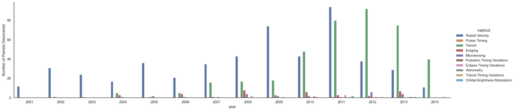

```python
with sns.axes_style('white'):
    g = sns.catplot(x="year", data=planets, aspect=4.0, kind='count',
    hue='method', order=range(2001, 2015))
    g.set_ylabels('Number of Planets Discovered')
```

图 4-125：不同年份、方法发现行星的数量（请到在线附录查看完 整图）